# BIOS 635: Naive Bayes

Kevin Donovan

1/28/2021

# Review

- Homework 3 due on 2/12 at 11PM through GitHub Classroom
- Article Evaluation 1 assigned, due on 2/9 through GitHub Classroom
- Last lecture: linear and quadratic discriminant analysis

# Discriminant Analysis

**Posterior Class Probability**:

$$\text{Pr}(Y=k|X=x)=\frac{f(x|k)*\text{Pr}(Y=k)}{\sum_{l=1}^{K} f(x|l)*\text{Pr}(Y=l)}$$

**Prediction Rule**: Given features $x_0$

$$\hat{y_0}=\underset{k=1,\ldots,K}{\operatorname{argmax}}\frac{f(x_0|k)*\text{Pr}(Y=k)}{\sum_{l=1}^{K} f(x_0|l)*\text{Pr}(Y=l)}=\underset{k=1,\ldots,K}{\operatorname{argmax}}f(x_0|k)*\text{Pr}(Y=k)$$

# LDA and QDA

$$\text{Pr}(Y=k|X=x)=\frac{f(x|k)*\text{Pr}(Y=k)}{\sum_{l=1}^{K} f(x|l)*\text{Pr}(Y=l)}$$

- Linear discriminant analysis (LDA)
  - Within classes, features are mutivariate normally distributed with **same** covariance structures $\leftrightarrow$
  - $f(x|k)\sim \text{Multivariate Normal}(\mu_k, \Sigma)$ for $k=1,\ldots,K$
- Quadratic discriminant analysis (QDA)
  - Within classes, features are mutivariate normally distributed with **possibly different** covariance structures $\leftrightarrow$
  - $f(x|k)\sim \text{Multivariate Normal}(\mu_k, \Sigma_k)$ for $k=1,\ldots,K$

# LDA vs logistic regression

For two-class prediction problem, can show for LDA, discriminant function $\rightarrow$

$$\text{log}\Bigg(\frac{\text{Pr}(Y=1|X=x)}{\text{Pr}(Y=0|X=x)}\Bigg)=c_0+c_1x_1+\ldots+c_px_p$$

and from logistic regression:

$$\text{logit}(p) =\text{log}\Bigg(\frac{\text{Pr}(Y=1|X=x)}{\text{Pr}(Y=0|X=x)}\Bigg)=\beta_0+\beta_1x_1+\ldots+\beta_px_p$$

so the two have the same form.

# LDA vs logistic regression

Difference = **how parameters are estimated**

- Logistic regression uses conditional likelihood based on $\text{Pr}(Y=1|X)$, denoted *discriminative learning*
- LDA uses **full likelihood** based on $f(x, y)$ with Bayes Rule, denoted *generative learning*
- However, in practice results often very similar

# LDA vs logistic regression differences

- When classes are **well separated**, i.e. $\text{Pr}(Y=1|X)$ near 0 or 1, logsitic regression coefficients are **very unstable**. Not the case with LDA
- LDA makes assumptions on the distribution of $X|Y=k$ (Normality, same covariance)
  - When assumptions hold, LDA can produce *more stable* decision boundaries, even with small $n$
- When $K=2$, due to a lack of assumptions on the distribution of $X|Y=k$, logisitic regression can be extended in many kinds of ways and is highly interpretable
  - Hard to interpret/implement well for $K>2$ classes. LDA is largely the same implementation-wise regardless of $K$

# Naive Bayes

**Recall**: Posterior class probability general form

$$\text{Pr}(Y=k|X=x)=\frac{f(x|k)*\text{Pr}(Y=k)}{\sum_{l=1}^{K} f(x|l)*\text{Pr}(Y=l)}$$

**Discriminant analysis**: alter form of $f(x|k)$ to get new method

- With normal distribution but different $\Sigma_k$ in each class $\rightarrow$ QDA
- Keeping normal distribution assumption, let’s assume **features are independent** in each class
  - This is **not** assuming features are *marginally independent*, i.e. independent in the entire population
  - Denoted *conditional independence*
  - For multivariate normal, this means $\Sigma_k$, **within-class feature correlations** are 0
  - In the likelihood, formulation is simplified as $\Sigma_k$ are diagonal
  - Method denoted as *Naive Bayes*

# Naive Bayes

- Simple structure very useful when number of predictors $p$ is large
- Ex. imagine $p=1000$ and $n=2000$. With LDA and QDA, estimating within-class correlations of features very difficult, even if equal correlations across classes is assumed (LDA)
  - Instead, Naive Bayes *assumes* components of $X=(X_1, \ldots, X_p)$ are independent
- Under independence, within-class feature distriubtion simplifies to:

$$\begin{align}
f(x|k)&=f(x_1, x_2, \ldots, x_p|k) \\
&=f(x_1|k)*\ldots*f(x_p|k) \\
&=\prod_{j=1}^{p}f(x_j|k)
\end{align}$$

- Multivariate densities go away, only need to estimate $p$ *univariate* densities $f(x_j|k)$

# Naive Bayes

- Assume each feature is normally distributed in each class
  - Discriminant function:

$$\begin{align}
\delta_k(x) &\propto \text{log}\Big[\Pr(Y=k)f(x|k)\Big] \\
&=\Pr(Y=k)\prod_{j=1}^p f(x_j|k) \text{ by independent features within class} \\
&=-\frac{1}{2}\sum_{j=1}^p \Big[\frac{(x_j-\mu_{kj})^2}{\sigma_{kj}^2} + \text{log}(\sigma_{kj}^2) \Big] + \text{log}[\Pr(Y=k)] \text{ by independent normality within class}
\end{align}$$

# Naive Bayes

- Ex. Heart disease prediction
- **Recall**: Had non-normal/categorical features

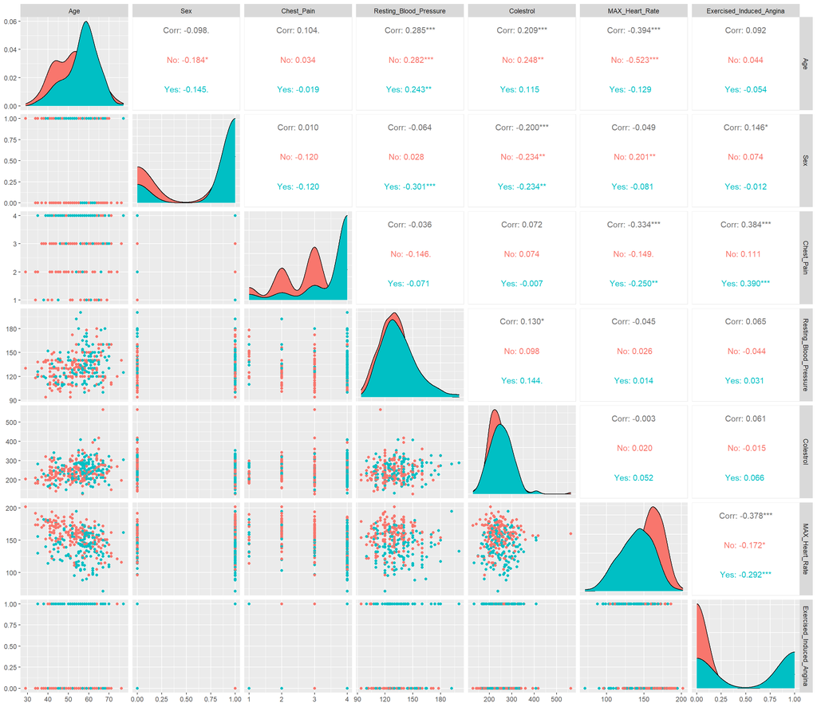

# Naive Bayes

- Ex. Heart disease prediction
- **Recall**: Had non-normal/categorical features
- **Note**: Need R package `klaR` to do in `caret`

```r
# Need to set categorical values to "factor" to get correct modeling of densities
heart_data <-
  heart_data %>%
  mutate(Sex=factor(Sex),
         Chest_Pain=factor(Chest_Pain),
         Exercised_Induced_Angina=factor(Exercised_Induced_Angina))

# Partition Data
set.seed(12)
train_test_indices <- createDataPartition(heart_data$heart_disease, p=0.6, list = FALSE)
heart_data_train <- heart_data[train_test_indices,]
heart_data_test <- heart_data[-train_test_indices,]

# Train
nb_fit <- train(heart_disease~Age+Sex+Chest_Pain+Resting_Blood_Pressure+Colestrol+
                MAX_Heart_Rate+Exercised_Induced_Angina,
                data = heart_data_train, method = "nb")

# Add in test set predictions
heart_data_test$estimated_prob_heart_disease <-
  predict(nb_fit, newdata=heart_data_test, type = "prob")$Yes

heart_data_test <-
  heart_data_test %>%
  mutate(pred_heart_disease =
           relevel(factor(ifelse(estimated_prob_heart_disease>0.5, "Yes", "No")),
                   ref = "No"))

# Compute confusion matrix
confusionMatrix(data = heart_data_test$pred_heart_disease,
                reference = heart_data_test$heart_disease,
                positive = "Yes")
```

```
## Confusion Matrix and Statistics
##
##           Reference
## Prediction No Yes
##        No  44  11
##        Yes 21  44
##
##                Accuracy : 0.7333
##                  95% CI : (0.6449, 0.8099)
##     No Information Rate : 0.5417
##     P-Value [Acc > NIR] : 1.243e-05
##
##                   Kappa : 0.4703
##
##  Mcnemar's Test P-Value : 0.1116
##
##             Sensitivity : 0.8000
##             Specificity : 0.6769
##          Pos Pred Value : 0.6769
##          Neg Pred Value : 0.8000
##              Prevalence : 0.4583
##          Detection Rate : 0.3667
##    Detection Prevalence : 0.5417
##       Balanced Accuracy : 0.7385
##
##        'Positive' Class : Yes
##
```

# Naive Bayes

- Ex. Heart disease prediction
- Can use `NaiveBayes` function in `klaR` package to see estimated conditional densities/distributions for each feature

```r
# Observe MLEs of parameters
nb_ests <- NaiveBayes(heart_disease~Age+Sex+Chest_Pain+Resting_Blood_Pressure+Colestrol+
                MAX_Heart_Rate+Exercised_Induced_Angina,
           data=heart_data_train,
           na.action = na.omit)

nb_ests$tables
```

```
## $Age
##         [,1]     [,2]
## No  52.62626 9.725399
## Yes 56.21429 8.269659
##
## $Sex
##         var
## grouping         0         1
##      No  0.4242424 0.5757576
##      Yes 0.1904762 0.8095238
##
## $Chest_Pain
##         var
## grouping          1          2          3          4
##      No  0.10101010 0.22222222 0.43434343 0.24242424
##      Yes 0.07142857 0.04761905 0.09523810 0.78571429
##
## $Resting_Blood_Pressure
##         [,1]     [,2]
## No  128.3030 15.82652
## Yes 135.1071 18.41753
##
## $Colestrol
##         [,1]     [,2]
## No  243.4747 56.21684
## Yes 245.4048 46.99478
##
## $MAX_Heart_Rate
##         [,1]     [,2]
## No  159.0303 19.78995
## Yes 136.9286 23.49611
##
## $Exercised_Induced_Angina
##         var
## grouping         0         1
##      No  0.8888889 0.1111111
##      Yes 0.4523810 0.5476190
```

# Naive Bayes

**Overview**:

- Training Phase:
  - For class $k$, estimate $\pi_k=\Pr(Y=k)$ using $\hat{\pi_k}=\frac{1}{n}\sum_{i=1}^{n}I(Y_i=k)$
  - For feature $X_j$
    - If $X_j$ is continuous, estimate $\text{E}(X_j|Y=k)=\mu_{x_j|k}$ and $\text{Var}(X_j|Y=k)=\sigma_{x_j|k}^2$ using within-class sample mean and variance
    - If $X_j$ is categorical, estimate $\text{Pr}(X_j=x_{jl}|Y=k)=\theta_{jlk}$ where $l$ is a category $X_j$ can take
    - Do so for each class $k$ in sample
- Testing Phase:
  - For subject with features $x_0=(x_{01}, \ldots, x_{0p})$, predict outcome $y_0$ using

$$\hat{y_0}=\underset{k=1,\ldots,K}{\operatorname{argmax}}\hat{\pi_k}\prod_{j=1}^{p}\hat{f}(x_{0j}|k)$$

- Where $\hat{f}(x_{0j}|k)$ is obtained by plugging in
  - conditional probabilities obtained in training if $X_j$ is categorical
  - conditional means and variances obtained in training if $X_j$ is continuous

# Naive Bayes

- Ex. Heart disease prediction

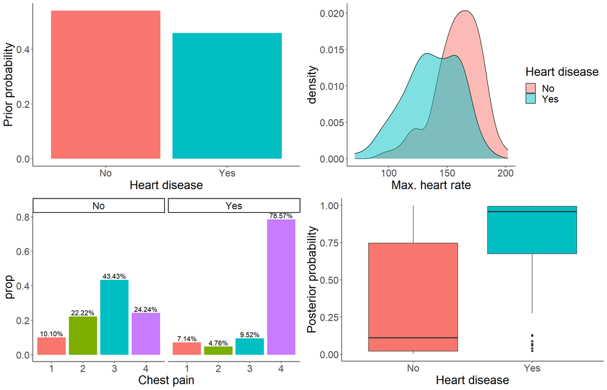

```r
# Plot "prior probabilities
prior_probs <- data.frame("heart_disease"=unname(names(nb_ests$apriori)),
                             "prior_prob"=as.numeric(nb_ests$apriori))
prior_probs_plot <-
  ggplot(data=prior_probs, mapping=aes(x=heart_disease, y=prior_prob,
                                       fill=heart_disease))+
  geom_bar(stat="identity")+
  labs(x="Heart disease", y="Prior probability")+
  theme_classic()+
  theme(legend.position = "none",
        text=element_text(size=20))

# Plot density for max heart rate
max_heart_rate_density <-
  ggplot(data=heart_data_train, mapping=aes(x=MAX_Heart_Rate,
                                            fill=heart_disease))+
  geom_density(alpha=0.5)+
  labs(fill="Heart disease", x="Max. heart rate")+
  theme_classic()+
  theme(text=element_text(size=20))

# Plot distribution for Chest_Pain
chest_pain_density <-
  ggplot(data=heart_data_train, mapping=aes(x=Chest_Pain,
                                            group=heart_disease))+
  geom_bar(aes(y = ..prop.., fill = factor(..x..)), stat="count")+
  geom_text(aes( label = scales::percent(..prop..),
                   y= ..prop.. ), stat= "count", vjust = -0.25,
            size=4) +
  facet_grid(~heart_disease)+
  labs(fill="", x="Chest pain")+
  theme_classic()+
  theme(legend.position = "none",
        text=element_text(size=20))

post_probs <-
  ggplot(data=heart_data_test,
         mapping=aes(x=heart_disease, y=estimated_prob_heart_disease,
                     fill=heart_disease))+
  geom_boxplot()+
  labs(x="Heart disease", y="Posterior probability")+
  theme_classic()+
  theme(legend.position = "none",
        text=element_text(size=20))

# Create 4-panel plot
ggarrange(plotlist = list(prior_probs_plot, max_heart_rate_density,
                          chest_pain_density, post_probs),
          ncol=2, nrow=2)
```

# Naive Bayes vs LDA vs QDA

- Naive Bayes scales well to problems where $p$ is large
  - Need large enough $n$ to estimate univariate properties of each feature
  - With LDA have $K*p$ parameters for $\text{E}(X_j|Y=k)$ and $0.5*p*(p+1)$ parameters for feature covariance matrix $\Sigma$
  - With QDA have $0.5*K*p*(p+1)$ parameters for the $K$ covariance matrices $\Sigma_k$
- However, LDA and QDA can capture and use **interactions in features** for prediction, Naive Bayes cannot

# Feature interaction example

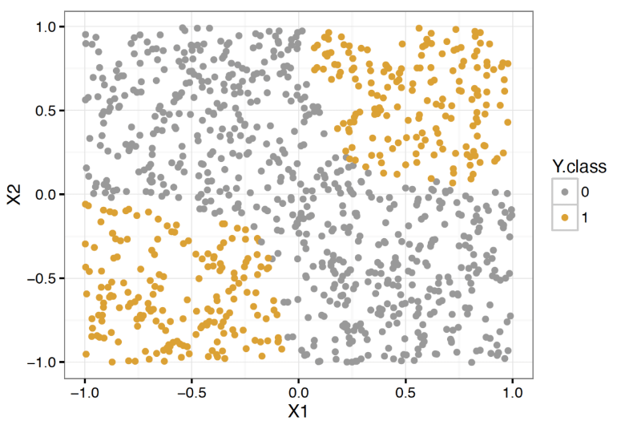

# Songs of the session

[Mexican Grand Prix by Mogwai](https://www.youtube.com/watch?v=BJZQ9xBrkWo)

[Your Hand in Mine by Explosion in the Sky](https://www.youtube.com/watch?v=cdiY6kijYHE)

[The Big Ship by Brian Eno](https://www.youtube.com/watch?v=lCCJc_V8_MQ)

[figure not shown]

[figure not shown]